# EUROVISION

Author

Germán Navascués y Laura Sánchez

# Introducción

Este análisis busca explorar cómo factores sociopolíticos, como el gasto en cultura o la estabilidad política, pueden influir en el desempeño de los países en Eurovisión, un evento que combina música y representación cultural a nivel internacional. Al integrar bases de datos con indicadores globales, esperamos identificar patrones que expliquen variaciones en el desempeño.

# Librerias y bases de datos

Nos descargamos las librerias.

```r
library(tidyverse)
library(haven)
library(car)
library(psych)
library(plotrix)
library(labelled)
library(Rcpp)
library(Hmisc)
library(devtools)
library(utils)
library(gmodels)
library(stargazer)
library(ggplot2)
library(e1071)
library(jtools)
library(ggstance)
library(huxtable)
library(arm)
library(lm.beta)
library(lmtest)
library(rms)
library(stargazer)
library(gvlma)
library(readxl)
library(data.table)
library (dplyr)
library(corrgram)
library(broom.mixed)
library(MASS)
library(gvlma)
library(mice)
library(lmtest)
library(corrplot)
library(sandwich)
```

Abrimos las bases de datos.

```r
qog <- read_dta("qogdata_10_01_2025.dta")

contestants <- read_csv("contestants.csv",
                        col_types = cols(
                          year = col_double(),
                          to_country = col_character(),
                          performer = col_character(),
                          song = col_character(),
                          place_final = col_double(),
                          points_final = col_double(),
                          points_tele_final = col_double(),
                          points_jury_final = col_double(),
                          points_tele_sf = col_double(),
                          points_jury_sf = col_double()
                        ), show_col_types = FALSE)

governance <- read_csv("aa.csv")
```

# Limpieza de las bases de datos

## QoG

Hemos cogido un QoG solo con las siguientes variables:

- Human Development Index (IDH): undp_hdi
- GDP per Capita: wdi_gdppppcur
- Government Expenditure on Recreation, Culture adn Religion: gfs_rcr
- Gasto militar: wdi_expmil
- Gasto educacion: wdi_expedu
- Political Stability and Absence of Violence/Terrorism:: wbgi_pve
- Conflict intensity: bti_ci
- Libertad de prensa: ciri_speech

```r
qog <- qog %>%
  rename(
    pais = cname,
    año = year,
    IDH = undp_hdi,
    PIB_pc = wdi_gdppppcur,
    gasto_cultura = gfs_rcr,
    gasto_militar = wdi_expmil,
    gasto_educacion = wdi_expedu,
    estabilidad_politica = wbgi_pve,
    intensidad_conflicto = bti_ci,
    libertad_prensa = ciri_speech )

qog <- qog %>%
  dplyr::select(-index, -ccodealp_year, -ccode, -ccode_qog, -cname_qog, -ccodealp, -ccodecow, -version, -cname_year)

colnames(qog)
```

```
 [1] "pais"                 "año"                  "IDH"
 [4] "gasto_cultura"        "intensidad_conflicto" "estabilidad_politica"
 [7] "libertad_prensa"      "gasto_militar"        "gasto_educacion"
[10] "PIB_pc"
```

## contestants

- Renombramos las variables de interés y quitamos las que no nos sirven.

```r
contestants <- contestants %>%
  rename(
    pais = to_country,
    año = year,
    artista = performer,
    cancion = song,
    posicion_concurso = place_contest,
    posicion_gfinal = place_final,
    puntos_gfinal = points_final)

contestants <- contestants %>%
  dplyr::select(-to_country_id, -sf_num, -running_final, -running_sf, -place_sf, -points_sf, -points_tele_final, -points_jury_final, -points_tele_sf, -points_jury_sf, -composers, -lyricists, -lyrics, -youtube_url)

colnames(contestants)
```

```
[1] "año"               "pais"              "artista"
[4] "cancion"           "posicion_concurso" "posicion_gfinal"
[7] "puntos_gfinal"
```

# Unión de las bases de datos (contestants y qog)

1. Mismo criterio para denominar a los países

```r
qog <- qog %>%
  mutate(pais = str_trim(tolower(pais)),
         pais = str_remove(pais, "\\(THE\\)$"),
         pais = str_remove_all(pais, "[:blank:]"))

contestants <- contestants %>%
  mutate(pais = str_trim(tolower(pais)))
```

- Número de paises y nombre de los mismos en la base qog

```r
unique_paises1 <- qog %>%
  distinct(pais) %>%
  arrange(pais)

num_paises1 <- nrow(unique_paises1)
list_paises1 <- unique_paises1$pais

cat("Número total de países:", num_paises1, "\n")
```

```
Número total de países: 199
```

```r
cat("Nombres de los países:\n") ## No salen porque son muchos y no queda bonito, falta hacer el print()
```

```
Nombres de los países:
```

- Número de paises y nombre de los mismos en la base contestants

```r
unique_paises2 <- contestants %>%
  distinct(pais) %>%
  arrange(pais)

num_paises2 <- nrow(unique_paises2)
list_paises2 <- unique_paises2$pais

cat("Número total de países:", num_paises2, "\n")
```

```
Número total de países: 54
```

```r
cat("Nombres de los países:\n")
```

```
Nombres de los países:
```

```r
print(list_paises2)
```

```
 [1] "albania"                    "andorra"
 [3] "armenia"                    "australia"
 [5] "austria"                    "azerbaijan"
 [7] "belarus"                    "belgium"
 [9] "bosnia & herzegovina"       "bulgaria"
[11] "croatia"                    "cyprus"
[13] "czech republic"             "czechia"
[15] "denmark"                    "estonia"
[17] "finland"                    "france"
[19] "georgia"                    "germany"
[21] "greece"                     "hungary"
[23] "iceland"                    "ireland"
[25] "israel"                     "italy"
[27] "latvia"                     "lithuania"
[29] "luxembourg"                 "malta"
[31] "moldova"                    "monaco"
[33] "montenegro"                 "morocco"
[35] "netherlands"                "north macedonia"
[37] "north macedonian.macedonia" "norway"
[39] "poland"                     "portugal"
[41] "romania"                    "russia"
[43] "san marino"                 "serbia"
[45] "serbia & montenegro"        "slovakia"
[47] "slovenia"                   "spain"
[49] "sweden"                     "switzerland"
[51] "turkey"                     "ukraine"
[53] "united kingdom"             "yugoslavia"
```

2. Revisar los países que no coinciden entre contestants y qog, recodificando en la base de datos qog
- Paises que se llaman distinto en qog: netherlands (the), united kingdom of great britain and northern ireland (the), bosnia and herzegovina, russian federation (the), serbia and montenegro, moldova (the republic of), czechia, north macedonia

```r
qog <- qog %>%
  mutate(
    pais = case_when(
      pais == "bosniaandherzegovina" ~ "bosnia & herzegovina",
      pais == "russianfederation(the)" ~ "russia",
      pais == "serbiaandmontenegro" ~ "serbia & montenegro",
      pais == "moldova(therepublicof)" ~ "moldova",
      pais == "netherlands(the)" ~ "netherlands",
      pais == "unitedkingdomofgreatbritainandnorthernireland(the)" ~ "united kingdom",
      pais == "czechia" ~ "czech republic",
      pais == "northmacedonia" ~ "north macedonia",
      TRUE ~ pais  # Mantener los demás sin cambios
    ))
```

3. Unión final de qog y contestants por país y año

*left_join*: Mantiene todas las filas de la tabla izquierda (en este caso, contestants) y añade las columnas coincidentes de la tabla derecha (qog). Es Útil para centrarnos en los registros existentes en contestants y añadir información de qog solo para los países/años presentes en Eurovisión.

```r
contestants_qog <- contestants %>%
  left_join(qog, by = c("pais", "año"))

table(contestants_qog$numleg, useNA = "ifany")
```

```
< table of extent 0 >
```

```r
dim(contestants_qog)
```

```
[1] 1734   15
```

- Comprobación final (54 países)

```r
# Ordenar alfabéticamente
unique_paises3 <- contestants_qog %>%
  distinct(pais) %>%
  arrange(pais)

num_paises3 <- nrow(unique_paises3)
list_paises3 <- unique_paises3$country

cat("Número total de países:", num_paises3, "\n")
```

```
Número total de países: 54
```

# Union de contestants_qog con governance

## governance

- Limpiar la base governance

```r
governance <- governance %>%
  rename(
    pais = `Country Name`,
    año = Time,
    control_corrupcion = `Control of Corruption: Estimate [CC.EST]`,
    efectividad_gobierno = `Government Effectiveness: Estimate [GE.EST]`,
    estabilidad_politica_violencia = `Political Stability and Absence of Violence/Terrorism: Estimate [PV.EST]`,
    calidad_regulatoria = `Regulatory Quality: Estimate [RQ.EST]`,
    estado_derecho = `Rule of Law: Estimate [RL.EST]`
  ) %>%
  mutate(
    pais = case_when(
      pais == "bosnia and herzegovina" ~ "bosnia & herzegovina",
      pais == "czechia" ~ "czech republic",
      pais == "slovak republic" ~ "slovakia",
      pais == "russian federation" ~ "russia",
      pais == "turkiye" ~ "turkey",
      TRUE ~ pais
    )
  ) %>%
  dplyr::select(-any_of(c("Time Code", "Country Code")))

colnames(governance)
```

```
[1] "año"                            "pais"
[3] "control_corrupcion"             "efectividad_gobierno"
[5] "estabilidad_politica_violencia" "calidad_regulatoria"
[7] "estado_derecho"
```

- Más comprobaciones

```r
governance <- governance %>%
  mutate(pais = str_trim(tolower(pais)))

unique_paises4<- governance %>%
  distinct(pais) %>%
  arrange(pais)

num_paises4 <- nrow(unique_paises4)
list_paises4 <- unique_paises4$pais

cat("Número total de países:", num_paises4, "\n")
```

```
Número total de países: 51
```

```r
cat("Nombres de los países:\n")
```

```
Nombres de los países:
```

```r
print(list_paises4)
```

```
 [1] "albania"                "andorra"                "armenia"
 [4] "australia"              "austria"                "azerbaijan"
 [7] "belarus"                "belgium"                "bosnia and herzegovina"
[10] "bulgaria"               "croatia"                "cyprus"
[13] "czechia"                "denmark"                "estonia"
[16] "finland"                "france"                 "georgia"
[19] "germany"                "greece"                 "hungary"
[22] "iceland"                "ireland"                "israel"
[25] "italy"                  "latvia"                 "lithuania"
[28] "luxembourg"             "malta"                  "moldova"
[31] "monaco"                 "montenegro"             "morocco"
[34] "netherlands"            "north macedonia"        "norway"
[37] "poland"                 "portugal"               "romania"
[40] "russian federation"     "san marino"             "serbia"
[43] "slovak republic"        "slovenia"               "spain"
[46] "sweden"                 "switzerland"            "turkiye"
[49] "ukraine"                "united kingdom"         NA
```

## Unión final

```r
contestants_qog <- contestants_qog %>%
  mutate(año = as.character(año))

governance <- governance %>%
  mutate(año = as.character(año))

data <- contestants_qog %>%
  left_join(governance, by = c("pais", "año"))

colnames(data)
```

```
 [1] "año"                            "pais"
 [3] "artista"                        "cancion"
 [5] "posicion_concurso"              "posicion_gfinal"
 [7] "puntos_gfinal"                  "IDH"
 [9] "gasto_cultura"                  "intensidad_conflicto"
[11] "estabilidad_politica"           "libertad_prensa"
[13] "gasto_militar"                  "gasto_educacion"
[15] "PIB_pc"                         "control_corrupcion"
[17] "efectividad_gobierno"           "estabilidad_politica_violencia"
[19] "calidad_regulatoria"            "estado_derecho"
```

- Ahora, filtraremos por año para quedarnos con los datos posteriores a 2002:

```r
data <- data %>%
  filter(año >= 2002)

colnames(data)
```

```
 [1] "año"                            "pais"
 [3] "artista"                        "cancion"
 [5] "posicion_concurso"              "posicion_gfinal"
 [7] "puntos_gfinal"                  "IDH"
 [9] "gasto_cultura"                  "intensidad_conflicto"
[11] "estabilidad_politica"           "libertad_prensa"
[13] "gasto_militar"                  "gasto_educacion"
[15] "PIB_pc"                         "control_corrupcion"
[17] "efectividad_gobierno"           "estabilidad_politica_violencia"
[19] "calidad_regulatoria"            "estado_derecho"
```

# Análisis de datos

## Cálculo del desempeño

La variable desempeño se calcula con 3 elementos: - si se ha ganado - si se ha llegado a la final - la media de puntos recibida (2002-2023)

```r
# Paso 1: Ganadores por año y número de victorias totales
ganadores <- data %>%
  filter(!is.na(posicion_gfinal)) %>%
  group_by(año) %>%
  filter(posicion_gfinal == 1) %>%
  ungroup() %>%
  count(pais, name = "total_victorias")

# Paso 2: Número de finales alcanzadas por país
finalistas <- data %>%
  filter(!is.na(posicion_gfinal)) %>%
  count(pais, name = "finales_alcanzadas")

# Paso 3: Media de puntos en la final por país
media_puntacion <- data %>%
  filter(!is.na(puntos_gfinal)) %>%
  group_by(pais) %>%
  summarise(promedio_puntos = mean(puntos_gfinal, na.rm = TRUE)) %>%
  ungroup()

# Paso 4: Crear una tabla de desempeño combinando los indicadores
desempeño_tabla <- ganadores %>%
  full_join(finalistas, by = "pais") %>%
  full_join(media_puntacion, by = "pais") %>%
  mutate(
    total_victorias = replace_na(total_victorias, 0),
    finales_alcanzadas = replace_na(finales_alcanzadas, 0),
    promedio_puntos = replace_na(promedio_puntos, 0)
  )

# Paso 5: Calcular puntuación combinada en una escala de 0 a 10
max_victorias <- max(desempeño_tabla$total_victorias, na.rm = TRUE)
max_finales <- max(desempeño_tabla$finales_alcanzadas, na.rm = TRUE)
max_puntos <- max(desempeño_tabla$promedio_puntos, na.rm = TRUE)

desempeño_tabla <- desempeño_tabla %>%
  mutate(
    desempeño_nota = (
      (total_victorias / max_victorias) * 5 +
      (finales_alcanzadas / max_finales) * 2.5 +
      (promedio_puntos / max_puntos) * 2.5
    ),
    desempeño_nota = (desempeño_nota / 10) * 10
  ) %>%
  arrange(desc(desempeño_nota))

print(desempeño_tabla)
```

```
# A tibble: 47 × 5
   pais       total_victorias finales_alcanzadas promedio_puntos desempeño_nota
   <chr>                <int>              <int>           <dbl>          <dbl>
 1 sweden                   3                 20           211.            9.25
 2 ukraine                  3                 18           201.            8.92
 3 italy                    1                 12           260.            5.39
 4 russia                   1                 17           189.            5.36
 5 norway                   1                 17           143.            4.96
 6 greece                   1                 18           123.            4.89
 7 germany                  1                 21            58.5           4.68
 8 azerbaijan               1                 13           145.            4.49
 9 israel                   1                 14           125             4.44
10 serbia                   1                 12           134.            4.28
# ℹ 37 more rows
```

## Cálculo del desempeño (LAG)

Vamos a crear una variable desempeño-lag por años, que se calcula igual que la anterior (en vez de media de puntos sería puntos cada año)

```r
# Paso 1: Calcular el número de victorias por país y año
ganadores_por_año <- data %>%
  filter(!is.na(posicion_gfinal)) %>%
  group_by(año, pais) %>%
  summarise(total_victorias = sum(posicion_gfinal == 1, na.rm = TRUE), .groups = "drop")

# Paso 2: Número de finales alcanzadas por país y año
finalistas_por_año <- data %>%
  filter(!is.na(posicion_gfinal)) %>%
  count(año, pais, name = "finales_alcanzadas")

# Paso 3: Media de puntos en la final por país y año
media_puntacion_por_año <- data %>%
  filter(!is.na(puntos_gfinal)) %>%
  group_by(año, pais) %>%
  summarise(promedio_puntos = mean(puntos_gfinal, na.rm = TRUE), .groups = "drop")

# Paso 4: Crear una tabla de desempeño por año
desempeño_por_año <- ganadores_por_año %>%
  full_join(finalistas_por_año, by = c("año", "pais")) %>%
  full_join(media_puntacion_por_año, by = c("año", "pais")) %>%
  mutate(
    total_victorias = replace_na(total_victorias, 0),
    finales_alcanzadas = replace_na(finales_alcanzadas, 0),
    promedio_puntos = replace_na(promedio_puntos, 0)
  )

# Paso 5: Calcular el performance_score por año
desempeño_por_año <- desempeño_por_año %>%
  group_by(año) %>%
  mutate(
    max_victorias = max(total_victorias, na.rm = TRUE),
    max_finales = max(finales_alcanzadas, na.rm = TRUE),
    max_puntos = max(promedio_puntos, na.rm = TRUE)
  ) %>%
  ungroup() %>%
  mutate(
    desempeño_nota = (
      (total_victorias / max_victorias) * 5 +
      (finales_alcanzadas / max_finales) * 2.5 +
      (promedio_puntos / max_puntos) * 2.5
    ),
    desempeño_nota = (desempeño_nota / 10) * 10
  )

# Paso 6: Crear la variable lag del desempeño_nota
desempeño_con_lag <- desempeño_por_año %>%
  arrange(pais, año) %>%
  group_by(pais) %>%
  mutate(
    lag_desempeño_nota = lag(desempeño_nota, n = 1)
  ) %>%
  ungroup()

# Mostrar tabla con variable lag
print(desempeño_con_lag)
```

```
# A tibble: 532 × 10
   año   pais   total_victorias finales_alcanzadas promedio_puntos max_victorias
   <chr> <chr>            <int>              <int>           <dbl>         <int>
 1 2004  alban…               0                  1             106             1
 2 2005  alban…               0                  1              53             1
 3 2008  alban…               0                  1              55             1
 4 2009  alban…               0                  1              48             1
 5 2010  alban…               0                  1              62             1
 6 2012  alban…               0                  1             146             1
 7 2015  alban…               0                  1              34             1
 8 2018  alban…               0                  1             184             1
 9 2019  alban…               0                  1              90             1
10 2021  alban…               0                  1              57             1
# ℹ 522 more rows
# ℹ 4 more variables: max_finales <int>, max_puntos <dbl>,
#   desempeño_nota <dbl>, lag_desempeño_nota <dbl>
```

## Incorporación de la variable desempeño y desempeño-la

- Combinación de la base desempeño_tabla (sin columna de año) con la base desempeño_con_lag

```r
desempeño_combi <- desempeño_con_lag %>%
  left_join(desempeño_tabla, by = "pais")
```

- Combinación de la base de data y la base combinada de desempeño

```r
data_final <- data %>%
  left_join(desempeño_combi, by = c("pais", "año"))
```

# Gestión de los NAs

Es necesario para poder realizar correctamente las regresiones.

- Verificación de valores que faltan y proporcion de los datos que se ven afectados

```r
na_data_final <- data_final %>%
  summarise(across(everything(), ~ mean(is.na(.)) * 100)) %>%
  pivot_longer(everything(), names_to = "variable", values_to = "percent_na") %>%
  arrange(desc(percent_na))

print(na_data_final)
```

```
# A tibble: 32 × 2
   variable             percent_na
   <chr>                     <dbl>
 1 intensidad_conflicto       79.9
 2 lag_desempeño_nota         43.0
 3 posicion_gfinal            38.8
 4 puntos_gfinal              38.8
 5 total_victorias.x          37.6
 6 finales_alcanzadas.x       37.6
 7 promedio_puntos.x          37.6
 8 max_victorias              37.6
 9 max_finales                37.6
10 max_puntos                 37.6
# ℹ 22 more rows
```

- Quitamos la variable intensidad de conflictos y estabilidad politica, ya que la base de datos governance nos permite indicadores mejores y muy parecidos con menos proporción de NAs.

```r
data_final <- data_final %>%
  dplyr::select(-intensidad_conflicto, -total_victorias.x, -finales_alcanzadas.x, -estabilidad_politica) %>%
  rename(
    desempeño_año = desempeño_nota.x,
    desempeño_media = desempeño_nota.y,
    total_victorias = total_victorias.y,
    finales_alcanzadas = finales_alcanzadas.y)

colnames(data_final)
```

```
 [1] "año"                            "pais"
 [3] "artista"                        "cancion"
 [5] "posicion_concurso"              "posicion_gfinal"
 [7] "puntos_gfinal"                  "IDH"
 [9] "gasto_cultura"                  "libertad_prensa"
[11] "gasto_militar"                  "gasto_educacion"
[13] "PIB_pc"                         "control_corrupcion"
[15] "efectividad_gobierno"           "estabilidad_politica_violencia"
[17] "calidad_regulatoria"            "estado_derecho"
[19] "promedio_puntos.x"              "max_victorias"
[21] "max_finales"                    "max_puntos"
[23] "desempeño_año"                  "lag_desempeño_nota"
[25] "total_victorias"                "finales_alcanzadas"
[27] "promedio_puntos.y"              "desempeño_media"
```

Ahora, veremos en qué países hay variables con casos perdidos.

```r
# Identificar los NAs: por país, año y variable
nas_info <- data_final %>%
  pivot_longer(cols = where(is.numeric), names_to = "variable", values_to = "valor") %>%
  filter(is.na(valor)) %>%
  group_by(pais, año, variable) %>%
  summarise(count = n(), .groups = "drop")

# Mostrar los países, años y variables con NAs, pero no ejecutaremos el codigo proque queda muy muy largo
# nas_info
```

Los NAs de la base de datos que corresponde a Eurovision pertenecen a los años que no han conseguido pasar a la final, por ello:

- Creación de una variable binaria para identificar si un país pasó a la final:

Finalista: 1 para los países que pasaron a la final, 0 para los eliminados.

```r
data_final <-  data_final %>%
  mutate(finalista = ifelse(is.na(posicion_gfinal), 0, 1),
          finalista = factor(
            finalista,
            levels = c(0, 1),
            labels = c("No Finalista", "Finalista")))
```

## Gestión de NAs de la parte de Eurovisión

```r
data_final <- data_final %>%
  mutate(
    max_victorias = ifelse(is.na(max_victorias), 1, max_victorias),
    max_finales = ifelse(is.na(max_finales), 1, max_finales),
    posicion_gfinal = ifelse(is.na(posicion_gfinal), 0, posicion_gfinal),
    puntos_gfinal = ifelse(is.na(puntos_gfinal), 0, puntos_gfinal),
    desempeño_año = ifelse(is.na(desempeño_año), 0, desempeño_año),
    promedio_puntos.x = ifelse(is.na(promedio_puntos.x), 0, promedio_puntos.x),
    promedio_puntos.y = ifelse(is.na(promedio_puntos.y), 0, promedio_puntos.y)
  ) %>%
  group_by(año) %>%
  mutate(
    max_puntos = ifelse(is.na(max_puntos),
                        max(puntos_gfinal, na.rm = TRUE),
                        max_puntos))
```

```r
data_final <- data_final %>%
  group_by(pais) %>%
  arrange(año, .by_group = TRUE) %>%  # Asegurar el orden correcto por país y año
  mutate(
    # Rellenar hacia atrás los valores dentro del grupo
    desempeño_media = zoo::na.locf(desempeño_media, na.rm = FALSE),
    # Rellenar hacia adelante los valores dentro del grupo
    desempeño_media = zoo::na.locf(desempeño_media, fromLast = TRUE, na.rm = FALSE)
  ) %>%
  ungroup()

data_final <- data_final %>%
  arrange(pais, año) %>%
  group_by(pais) %>%
  mutate(
    lag_desempeño_nota = case_when(
      año %in% c(2002, 2003) & is.na(lag_desempeño_nota) ~ 0,
      is.na(lag_desempeño_nota) ~ lag(desempeño_año, order_by = año, default = NA),
      TRUE ~ lag_desempeño_nota
    )
  ) %>%
  ungroup()

data_final <- data_final %>%
  group_by(pais) %>%
  mutate(
    finales_alcanzadas = ifelse(is.na(finales_alcanzadas),
                                first(finales_alcanzadas[!is.na(finales_alcanzadas)]),
                                finales_alcanzadas),
    total_victorias = ifelse(is.na(total_victorias),
                             first(total_victorias[!is.na(total_victorias)]),
                             total_victorias)
  ) %>%
  ungroup()
```

- Verificación de valores que faltan y proporción de los datos que se ven afectados tras la imputación de datos. También quitaremos Andorra, Mónaco y el año 2020 (covid) que no tiene datos.

```r
data_final <- data_final %>%
  filter(pais != "andorra")

data_final <- data_final %>%
  filter(pais != "monaco")

data_final <- data_final %>%
  filter(año !="2020")


na_data_final <- data_final %>%
  summarise(across(everything(), ~ mean(is.na(.)) * 100)) %>%
  pivot_longer(everything(), names_to = "variable", values_to = "percent_na") %>%
  arrange(desc(percent_na))

print(na_data_final)
```

```
# A tibble: 29 × 2
   variable                       percent_na
   <chr>                               <dbl>
 1 gasto_cultura                       24.3
 2 gasto_educacion                     19.8
 3 IDH                                 13.1
 4 libertad_prensa                     12.9
 5 gasto_militar                       10.9
 6 PIB_pc                               8.55
 7 control_corrupcion                   6.96
 8 efectividad_gobierno                 6.96
 9 estabilidad_politica_violencia       6.96
10 calidad_regulatoria                  6.96
# ℹ 19 more rows
```

## Imputacion NAs de QoG

Es necesario imputar NAs para hacer correctamente las regresiones. Por ello, imputaremos los NAs del QoG con mice, ya que tienen un porcentaje medio-alto de NAs (entre un 10 y un 25%).

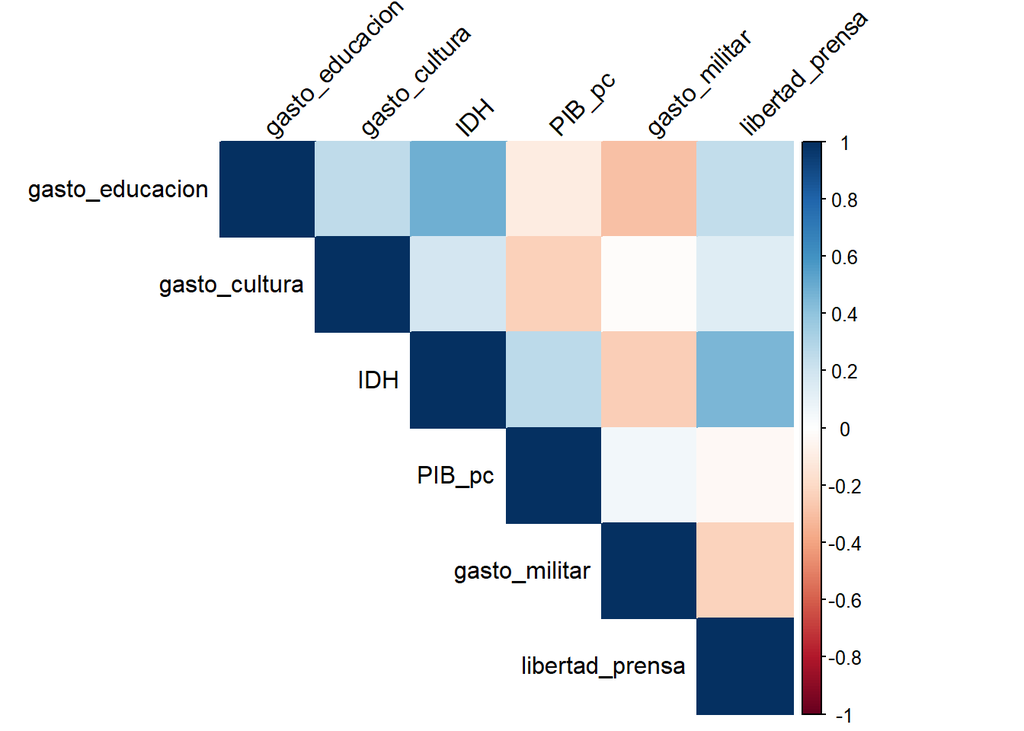

```r
# Seleccionar las variables a imputar
variables_para_imputar1 <- data_final %>%
  dplyr::select(gasto_educacion, gasto_cultura, IDH, PIB_pc, gasto_militar, libertad_prensa)

cor_matrix <- cor(variables_para_imputar1, use = "pairwise.complete.obs")
corrplot::corrplot(cor_matrix, method = "color", type = "upper", tl.col = "black", tl.srt = 45)
```

Como podemos ver, hay cierta correlación entre ellas, por lo que no imputaremos todas. Nos quedaremos con el IDH y dejaremos fuera el PIB, por el momento.

```r
variables_para_imputar <- data_final %>%
  dplyr::select(gasto_educacion, gasto_cultura, IDH, gasto_militar, libertad_prensa)


# Realizar la imputación con mice
imputacion <- mice(variables_para_imputar, method = "pmm", m = 5, seed = 123)
# Completar los valores imputados
variables_imputadas <- complete(imputacion)

# Sustituir las variables originales en data_final por las imputadas
data_final <- data_final %>%
  mutate(
    gasto_educacion = variables_imputadas$gasto_educacion,
    gasto_cultura = variables_imputadas$gasto_cultura,
    IDH = variables_imputadas$IDH,
    gasto_militar = variables_imputadas$gasto_militar,
    libertad_prensa = variables_imputadas$libertad_prensa
  )
```

## Imputación NAs de governance

```r
# Convertir las variables a numéricas
data_final <- data_final %>%
  mutate(
    control_corrupcion = as.numeric(control_corrupcion),
    efectividad_gobierno = as.numeric(efectividad_gobierno),
    estabilidad_politica_violencia = as.numeric(estabilidad_politica_violencia),
    calidad_regulatoria = as.numeric(calidad_regulatoria),
    estado_derecho = as.numeric(estado_derecho)
  )

# Imputar los valores faltantes con la media por país
data_final <- data_final %>%
  group_by(pais) %>%
  mutate(
    control_corrupcion = ifelse(is.na(control_corrupcion),
                                mean(control_corrupcion, na.rm = TRUE),
                                control_corrupcion),
    efectividad_gobierno = ifelse(is.na(efectividad_gobierno),
                                  mean(efectividad_gobierno, na.rm = TRUE),
                                  efectividad_gobierno),
    estabilidad_politica_violencia = ifelse(is.na(estabilidad_politica_violencia),
                                            mean(estabilidad_politica_violencia, na.rm = TRUE),
                                            estabilidad_politica_violencia),
    calidad_regulatoria = ifelse(is.na(calidad_regulatoria),
                                 mean(calidad_regulatoria, na.rm = TRUE),
                                 calidad_regulatoria),
    estado_derecho = ifelse(is.na(estado_derecho),
                            mean(estado_derecho, na.rm = TRUE),
                            estado_derecho)
  ) %>%
   ungroup() %>%
  mutate(
    # Si todavía quedan NA (grupos completos eran NA), imputar con la media global
    control_corrupcion = ifelse(is.na(control_corrupcion), mean(control_corrupcion, na.rm = TRUE), control_corrupcion),
    efectividad_gobierno = ifelse(is.na(efectividad_gobierno), mean(efectividad_gobierno, na.rm = TRUE), efectividad_gobierno),
    estabilidad_politica_violencia = ifelse(is.na(estabilidad_politica_violencia), mean(estabilidad_politica_violencia, na.rm = TRUE), estabilidad_politica_violencia),
    calidad_regulatoria = ifelse(is.na(calidad_regulatoria), mean(calidad_regulatoria, na.rm = TRUE), calidad_regulatoria),
    estado_derecho = ifelse(is.na(estado_derecho), mean(estado_derecho, na.rm = TRUE), estado_derecho)
  )

summary(data_final %>%
          dplyr::select(control_corrupcion, efectividad_gobierno, estabilidad_politica_violencia, calidad_regulatoria, estado_derecho))
```

```
 control_corrupcion efectividad_gobierno estabilidad_politica_violencia
 Min.   :-1.24537   Min.   :-1.2098      Min.   :-2.0208
 1st Qu.: 0.04274   1st Qu.: 0.4048      1st Qu.: 0.1797
 Median : 0.80947   Median : 0.9655      Median : 0.5737
 Mean   : 0.80947   Mean   : 0.8959      Mean   : 0.4945
 3rd Qu.: 1.62201   3rd Qu.: 1.5463      3rd Qu.: 0.9409
 Max.   : 2.45912   Max.   : 2.3472      Max.   : 1.7532
 calidad_regulatoria estado_derecho
 Min.   :-1.5962     Min.   :-1.3037
 1st Qu.: 0.5483     1st Qu.: 0.2414
 Median : 0.9821     Median : 0.9375
 Mean   : 0.9399     Mean   : 0.8537
 3rd Qu.: 1.4922     3rd Qu.: 1.6269
 Max.   : 2.0405     Max.   : 2.1248
```

Estrategia basada en el porcentaje de NAs:

1. Variables con pocos NAs (menos del 10%):

Puedes rellenar los NAs utilizando la media. Esto preserva la mayor parte de la información sin distorsionar los resultados.

2. Variables con NAs moderados (entre 10% y 30%):

Consideramos realizar imputaciones más robustas, como modelos predictivos, en el caso de los datos del QoG, los cuales tenían mas datos perdidos.

A la hora de tratar los casos perdidos encontramos diferentes opciones. El caso es que hay ciertas variables como control_corrupcion, estado_derecho, calidad_regulatoria, estabilidad_politica_violencia y efectividad_gobierno las cuales están estandarizadas en una escala de -2.5 a 2.5, donde los valores negativos suelen indicar un peor desempeño y los valores positivos un mejor desempeño en la dimensión correspondiente. Un 0 dentro de este rango representa un desempeño “neutral” o promedio, no una ausencia de datos. Las estimaciones en el modelo de regresión podrían estar sesgadas, ya que el 0 artificialmente asignado sería tratado como un dato válido, alterando las relaciones reales entre la variable independiente y el desempeño.

Por estos motivos, y al no ser los NAs muy elevados, vamos a tratarlos con la media.

# REGRESIONES

Una vez listas nuestras variables vamos a crear un dataframe con aquello que vamos a comparar y tambien eliminaremos los na que aún quedan.

```r
data_regre <- data_final %>%
  dplyr::select(desempeño_media, año, pais, posicion_concurso, posicion_gfinal, puntos_gfinal, IDH, gasto_cultura, gasto_educacion, libertad_prensa, gasto_militar, control_corrupcion, efectividad_gobierno, estado_derecho, estabilidad_politica_violencia, lag_desempeño_nota) %>% drop_na()

summary(data_regre)
```

```
 desempeño_media      año                pais           posicion_concurso
 Min.   :0.5959   Length:782         Length:782         Min.   : 1.00
 1st Qu.:2.1222   Class :character   Class :character   1st Qu.:10.00
 Median :2.7274   Mode  :character   Mode  :character   Median :20.00
 Mean   :3.3069                                         Mean   :19.92
 3rd Qu.:4.1928                                         3rd Qu.:29.00
 Max.   :9.2471                                         Max.   :43.00
 posicion_gfinal  puntos_gfinal         IDH         gasto_cultura
 Min.   : 0.000   Min.   :  0.00   Min.   :0.6750   Min.   :0.9237
 1st Qu.: 0.000   1st Qu.:  0.00   1st Qu.:0.8020   1st Qu.:2.1774
 Median : 7.000   Median : 39.50   Median :0.8650   Median :2.6219
 Mean   : 8.868   Mean   : 79.43   Mean   :0.8518   Mean   :2.8505
 3rd Qu.:16.000   3rd Qu.:115.00   3rd Qu.:0.9080   3rd Qu.:3.2495
 Max.   :27.000   Max.   :758.00   Max.   :0.9620   Max.   :9.0633
 gasto_educacion libertad_prensa gasto_militar     control_corrupcion
 Min.   :1.906   Min.   :0.000   Min.   : 0.2251   Min.   :-1.24537
 1st Qu.:4.127   1st Qu.:1.000   1st Qu.: 1.1626   1st Qu.: 0.05317
 Median :5.015   Median :1.000   Median : 1.4521   Median : 0.80947
 Mean   :5.051   Mean   :1.211   Mean   : 1.7836   Mean   : 0.82291
 3rd Qu.:5.739   3rd Qu.:2.000   3rd Qu.: 1.9763   3rd Qu.: 1.64860
 Max.   :9.510   Max.   :2.000   Max.   :33.5466   Max.   : 2.45912
 efectividad_gobierno estado_derecho    estabilidad_politica_violencia
 Min.   :-1.2098      Min.   :-1.3037   Min.   :-2.0208
 1st Qu.: 0.4228      1st Qu.: 0.2551   1st Qu.: 0.1840
 Median : 0.9770      Median : 0.9548   Median : 0.5775
 Mean   : 0.9075      Mean   : 0.8660   Mean   : 0.5028
 3rd Qu.: 1.5539      3rd Qu.: 1.6367   3rd Qu.: 0.9469
 Max.   : 2.3472      Max.   : 2.1248   Max.   : 1.7532
 lag_desempeño_nota
 Min.   : 0.000
 1st Qu.: 2.525
 Median : 2.869
 Mean   : 2.626
 3rd Qu.: 3.371
 Max.   :10.000
```

Pasamos de 819 observaciones a 782 observaciones.

Examina las relaciones entre las variables para identificar posibles multicolinealidades.

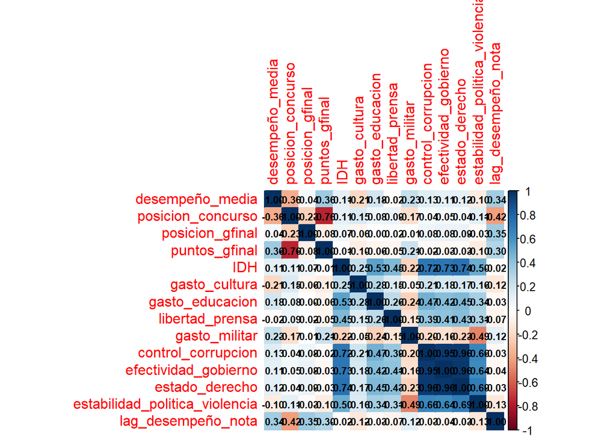

```r
# Seleccionar variables numéricas relevantes
comprobar_corre <- data_regre %>%
  dplyr::select(desempeño_media, año, pais, posicion_concurso, posicion_gfinal, puntos_gfinal, IDH, gasto_cultura, gasto_educacion, libertad_prensa, gasto_militar, control_corrupcion, estabilidad_politica_violencia, lag_desempeño_nota)

comprobar_corre <- data_regre %>%
  dplyr::select(where(is.numeric))

# Matriz de correlación
matriz_correlacion <- cor(comprobar_corre, use = "pairwise.complete.obs")
corrplot(matriz_correlacion, method = "color", addCoef.col = "black", number.cex = 0.7)
```

Interpretación general

- **Agrupaciones naturales**: Las variables relacionadas con gobernanza y estabilidad (control_corrupcion, efectividad_gobierno, estado_derecho, estabilidad_politica_violencia) tienen correlaciones altas entre sí, formando un grupo claro de variables relacionadas.
- **Variables predictoras clave**: Factores como `IDH`, `control_corrupcion` y `estabilidad_politica_violencia` probablemente tengan un papel importante en explicar el desempeño, dada su fuerte relación con otras variables clave.
- **Relaciones débiles o contraintuitivas**: La relación negativa entre gasto_cultura y el desempeño merece un análisis más profundo, ya que podría estar influenciada por outliers o efectos indirectos.

# Regresión lineal

## Modelos simples para las hipotesis

```r
# Regresión simple: gasto_cultura
modelo_cultura <- lm(desempeño_media ~ gasto_cultura, data = data_regre)
summary(modelo_cultura)
```

```
Call:
lm(formula = desempeño_media ~ gasto_cultura, data = data_regre)

Residuals:
    Min      1Q  Median      3Q     Max
-3.0408 -1.2230 -0.3657  0.8940  6.0563

Coefficients:
              Estimate Std. Error t value Pr(>|t|)
(Intercept)    4.14196    0.15519  26.689  < 2e-16 ***
gasto_cultura -0.29294    0.04985  -5.876 6.23e-09 ***
---
Signif. codes:  0 '***' 0.001 '**' 0.01 '*' 0.05 '.' 0.1 ' ' 1

Residual standard error: 1.744 on 780 degrees of freedom
Multiple R-squared:  0.04239,   Adjusted R-squared:  0.04116
F-statistic: 34.53 on 1 and 780 DF,  p-value: 6.23e-09
```

```r
# Regresión simple: IDH
modelo_idh <- lm(desempeño_media ~ IDH, data = data_regre)
summary(modelo_idh)
```

```
Call:
lm(formula = desempeño_media ~ IDH, data = data_regre)

Residuals:
    Min      1Q  Median      3Q     Max
-2.8460 -1.1941 -0.3969  0.9226  6.0191

Coefficients:
            Estimate Std. Error t value Pr(>|t|)
(Intercept)   0.7654     0.7898   0.969   0.3328
IDH           2.9839     0.9242   3.229   0.0013 **
---
Signif. codes:  0 '***' 0.001 '**' 0.01 '*' 0.05 '.' 0.1 ' ' 1

Residual standard error: 1.77 on 780 degrees of freedom
Multiple R-squared:  0.01319,   Adjusted R-squared:  0.01192
F-statistic: 10.42 on 1 and 780 DF,  p-value: 0.001296
```

```r
# Regresión simple: estabilidad_politica_violencia
modelo_estabilidad <- lm(desempeño_media ~ estabilidad_politica_violencia, data = data_regre)
summary(modelo_estabilidad)
```

```
Call:
lm(formula = desempeño_media ~ estabilidad_politica_violencia,
    data = data_regre)

Residuals:
    Min      1Q  Median      3Q     Max
-2.8967 -1.1871 -0.5711  0.9406  6.2207

Coefficients:
                               Estimate Std. Error t value Pr(>|t|)
(Intercept)                     3.45197    0.08049  42.885  < 2e-16 ***
estabilidad_politica_violencia -0.28846    0.09869  -2.923  0.00357 **
---
Signif. codes:  0 '***' 0.001 '**' 0.01 '*' 0.05 '.' 0.1 ' ' 1

Residual standard error: 1.772 on 780 degrees of freedom
Multiple R-squared:  0.01083,   Adjusted R-squared:  0.009566
F-statistic: 8.543 on 1 and 780 DF,  p-value: 0.003569
```

```r
# Regresión simple: gasto_militar
modelo_militar <- lm(desempeño_media ~ gasto_militar, data = data_regre)
summary(modelo_militar)
```

```
Call:
lm(formula = desempeño_media ~ gasto_militar, data = data_regre)

Residuals:
    Min      1Q  Median      3Q     Max
-3.4463 -1.1188 -0.4269  0.9279  6.1399

Coefficients:
              Estimate Std. Error t value Pr(>|t|)
(Intercept)    2.83858    0.09344  30.378  < 2e-16 ***
gasto_militar  0.26260    0.03921   6.697 4.07e-11 ***
---
Signif. codes:  0 '***' 0.001 '**' 0.01 '*' 0.05 '.' 0.1 ' ' 1

Residual standard error: 1.733 on 780 degrees of freedom
Multiple R-squared:  0.05437,   Adjusted R-squared:  0.05316
F-statistic: 44.85 on 1 and 780 DF,  p-value: 4.068e-11
```

```r
# Regresión simple: posicion_concurso
modelo_posicion <- lm(desempeño_media ~ posicion_concurso, data = data_regre)
summary(modelo_posicion)
```

```
Call:
lm(formula = desempeño_media ~ posicion_concurso, data = data_regre)

Residuals:
    Min      1Q  Median      3Q     Max
-3.1003 -1.1771 -0.3027  0.9163  6.2822

Coefficients:
                   Estimate Std. Error t value Pr(>|t|)
(Intercept)        4.427357   0.119187   37.15   <2e-16 ***
posicion_concurso -0.056247   0.005187  -10.84   <2e-16 ***
---
Signif. codes:  0 '***' 0.001 '**' 0.01 '*' 0.05 '.' 0.1 ' ' 1

Residual standard error: 1.661 on 780 degrees of freedom
Multiple R-squared:  0.131, Adjusted R-squared:  0.1299
F-statistic: 117.6 on 1 and 780 DF,  p-value: < 2.2e-16
```

Para entender el efecto de todas las variables independientes:

```r
modelo_1 <- lm(desempeño_media ~ gasto_cultura + IDH + estabilidad_politica_violencia + gasto_militar + posicion_concurso, data = data_regre)
summary(modelo_1)
```

```
Call:
lm(formula = desempeño_media ~ gasto_cultura + IDH + estabilidad_politica_violencia +
    gasto_militar + posicion_concurso, data = data_regre)

Residuals:
    Min      1Q  Median      3Q     Max
-3.1692 -1.0063 -0.2598  0.7168  5.9980

Coefficients:
                                Estimate Std. Error t value Pr(>|t|)
(Intercept)                    -1.467367   0.781977  -1.876   0.0610 .
gasto_cultura                  -0.291185   0.046299  -6.289 5.32e-10 ***
IDH                             7.443377   0.956982   7.778 2.35e-14 ***
estabilidad_politica_violencia -0.238480   0.112166  -2.126   0.0338 *
gasto_militar                   0.211606   0.040852   5.180 2.83e-07 ***
posicion_concurso              -0.049864   0.004982 -10.009  < 2e-16 ***
---
Signif. codes:  0 '***' 0.001 '**' 0.01 '*' 0.05 '.' 0.1 ' ' 1

Residual standard error: 1.554 on 776 degrees of freedom
Multiple R-squared:  0.2439,    Adjusted R-squared:  0.2391
F-statistic: 50.07 on 5 and 776 DF,  p-value: < 2.2e-16
```

Estas explican 0.24, vemos que el otro modelo explica mejor. Asi que revisaremos los supuestos básicos de la regresion en el modelo_2:

```r
modelo_2 <- lm(desempeño_media ~ posicion_concurso + puntos_gfinal + IDH + gasto_cultura + gasto_educacion + libertad_prensa + gasto_militar + control_corrupcion + estabilidad_politica_violencia + lag_desempeño_nota, data = data_regre)

summary(modelo_2)
```

```
Call:
lm(formula = desempeño_media ~ posicion_concurso + puntos_gfinal +
    IDH + gasto_cultura + gasto_educacion + libertad_prensa +
    gasto_militar + control_corrupcion + estabilidad_politica_violencia +
    lag_desempeño_nota, data = data_regre)

Residuals:
    Min      1Q  Median      3Q     Max
-3.0208 -1.0062 -0.2231  0.6950  5.9689

Coefficients:
                                 Estimate Std. Error t value Pr(>|t|)
(Intercept)                     0.7633671  0.9230660   0.827 0.408498
posicion_concurso              -0.0159504  0.0075470  -2.113 0.034881 *
puntos_gfinal                   0.0026493  0.0007507   3.529 0.000442 ***
IDH                             1.2423638  1.2249149   1.014 0.310784
gasto_cultura                  -0.3360269  0.0440628  -7.626 7.13e-14 ***
gasto_educacion                 0.3487176  0.0475506   7.334 5.68e-13 ***
libertad_prensa                -0.1073592  0.0961624  -1.116 0.264583
gasto_militar                   0.1970657  0.0397771   4.954 8.93e-07 ***
control_corrupcion              0.3478301  0.0955967   3.639 0.000292 ***
estabilidad_politica_violencia -0.4147373  0.1235501  -3.357 0.000827 ***
lag_desempeño_nota              0.1865538  0.0307980   6.057 2.16e-09 ***
---
Signif. codes:  0 '***' 0.001 '**' 0.01 '*' 0.05 '.' 0.1 ' ' 1

Residual standard error: 1.449 on 771 degrees of freedom
Multiple R-squared:  0.3468,    Adjusted R-squared:  0.3383
F-statistic: 40.93 on 10 and 771 DF,  p-value: < 2.2e-16
```

```r
library(stargazer)

stargazer(modelo_2,
          type="text",
          dep.var.labels=c("Desempeño en Eurovisión"),
          covariate.labels=c("Posición en el concurso","Puntos finales", "IDH", "Gasto en cultura", "Gasto en educación", "Libertad de prensa", "Gasto militar", "Control de la corrupción", "Estabilidad politica y violencia", "Desempeño con lag", "Constante"))
```

```
============================================================
                                     Dependent variable:
                                 ---------------------------
                                   Desempeño en Eurovisión
------------------------------------------------------------
Posición en el concurso                   -0.016**
                                           (0.008)

Puntos finales                            0.003***
                                           (0.001)

IDH                                         1.242
                                           (1.225)

Gasto en cultura                          -0.336***
                                           (0.044)

Gasto en educación                        0.349***
                                           (0.048)

Libertad de prensa                         -0.107
                                           (0.096)

Gasto militar                             0.197***
                                           (0.040)

Control de la corrupción                  0.348***
                                           (0.096)

Estabilidad politica y violencia          -0.415***
                                           (0.124)

Desempeño con lag                         0.187***
                                           (0.031)

Constante                                   0.763
                                           (0.923)

------------------------------------------------------------
Observations                                 782
R2                                          0.347
Adjusted R2                                 0.338
Residual Std. Error                   1.449 (df = 771)
F Statistic                       40.927*** (df = 10; 771)
============================================================
Note:                            *p<0.1; **p<0.05; ***p<0.01
```

Para medir cuánto explican las variables independientes de la variabilidad de la variable dependiente (desempeño_media), usaremos un modelo de regresión lineal y evaluaremos el R² (coeficiente de determinación). Este valor mide la proporción de la varianza de la variable dependiente explicada por las independientes.

El R² ajustado es una versión ajustada de R² que penaliza la inclusión de variables irrelevantes:

```r
r2_ajustado <- summary(modelo_2)$adj.r.squared
print(r2_ajustado)
```

```
[1] 0.3382879
```

- Normalidad de los residuos:

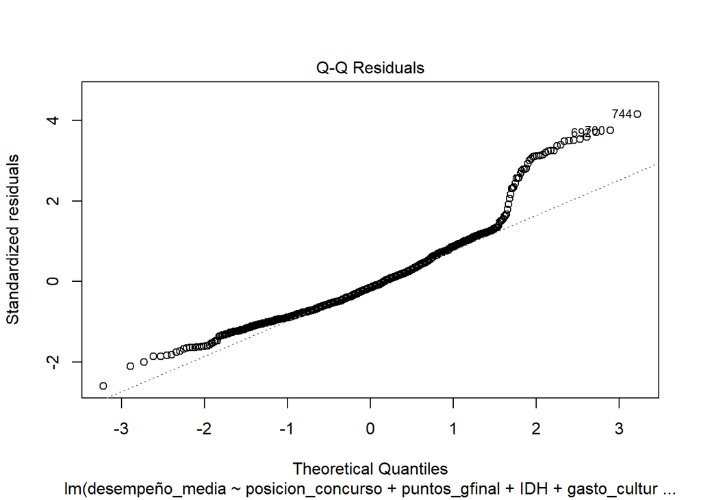

```r
plot(modelo_2, which = 2)
```

Observación:

El gráfico Q-Q muestra que los residuos no siguen perfectamente una distribución normal: - En los extremos, los puntos se desvían notablemente de la línea diagonal (derecha e izquierda). - Hay puntos con valores altos de residuos estandarizados (outliers), como el marcado con el índice 744.

La falta de normalidad puede indicar que: - Existen outliers en los datos. - El modelo puede no capturar completamente la relación entre las variables. - Puede ser necesario realizar transformaciones en las variables dependientes o independientes para mejorar la normalidad de los residuos.

```r
data_regre[744, ]  # Revisar el caso 744
```

| desempeño_media | año | pais | posicion_concurso | posicion_gfinal | puntos_gfinal | IDH | gasto_cultura | gasto_educacion | libertad_prensa | gasto_militar | control_corrupcion | efectividad_gobierno | estado_derecho | estabilidad_politica_violencia | lag_desempeño_nota |
| --- | --- | --- | --- | --- | --- | --- | --- | --- | --- | --- | --- | --- | --- | --- | --- |
| 8.92 | 2003 | ukraine | 14 | 14 | 30 | 0.732 | 2.06 | 5.4 | 0 | 2.12 | -0.967 | -0.674 | -0.823 | -0.364 | 0 |

```r
data_regre[700, ]
```

| desempeño_media | año | pais | posicion_concurso | posicion_gfinal | puntos_gfinal | IDH | gasto_cultura | gasto_educacion | libertad_prensa | gasto_militar | control_corrupcion | efectividad_gobierno | estado_derecho | estabilidad_politica_violencia | lag_desempeño_nota |
| --- | --- | --- | --- | --- | --- | --- | --- | --- | --- | --- | --- | --- | --- | --- | --- |
| 9.25 | 2010 | sweden | 26 | 0 | 0 | 0.91 | 2.58 | 6.52 | 1 | 1.19 | 2.22 | 1.96 | 1.93 | 1.09 | 2.71 |

Deberíamos tratarlo, pero no tenemos tiempo suficiente.

- Homocedasticidad:

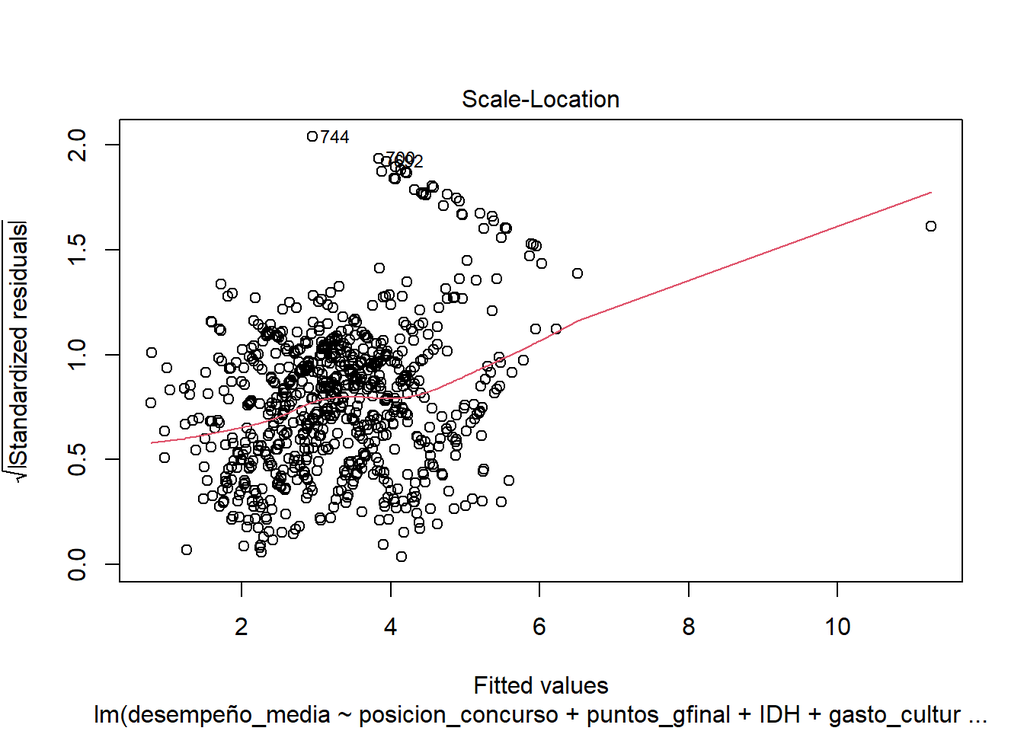

```r
plot(modelo_2, which = 3)
```

```r
bptest(modelo_2)  # Test de Breusch-Pagan para heterocedasticidad
```

```
    studentized Breusch-Pagan test

data:  modelo_2
BP = 118.91, df = 10, p-value < 2.2e-16
```

El test de Breusch-Pagan confirma que hay heterocedasticidad en el modelo, ya que el valor p (< 2.2e-16) es extremadamente significativo. Esto indica que los residuos no tienen varianza constante, lo cual viola un supuesto clave de la regresión lineal.

- Multicolinealidad (VIF):

Revisaremos si las variables están correlacionadas excesivamente.

```r
vif(modelo_2)
```

```
             posicion_concurso                  puntos_gfinal
                      2.783466                       2.525583
                           IDH                  gasto_cultura
                      2.623002                       1.131909
               gasto_educacion                libertad_prensa
                      1.509949                       1.278535
                 gasto_militar             control_corrupcion
                      1.472534                       3.022462
estabilidad_politica_violencia             lag_desempeño_nota
                      2.345737                       1.243676
```

Los valores de VIF (Variance Inflation Factor) para las variables independientes están por debajo de 10, lo que indica que no hay multicolinealidad significativa. - La variable con el VIF más alto es control_corrupcion (3.02), pero sigue dentro de un rango aceptable.

Interpretación:

- Los valores de VIF sugieren que las variables independientes no están excesivamente correlacionadas entre sí.
- Sin embargo, puedes considerar eliminar variables con poca significancia para simplificar el modelo, es decir, variables con > 0.05 pueden ser eliminadas.

## Uso de regresion robusta para el manejo de la heterocedasticidad

*Disclaimer*: **Aquí entramos en un terreno de pensar por nuestra cuenta, yendo un poco más allá de lo que hemos aprendido aun, asi que no nuestro nivel de confianza sobre lo que viene a continuación es de un 70%**

```r
# Estimación robusta de errores estándar
coeftest(modelo_2, vcov = vcovHC(modelo_2, type = "HC1"))
```

```
t test of coefficients:

                                  Estimate  Std. Error t value  Pr(>|t|)
(Intercept)                     0.76336705  0.80909571  0.9435 0.3457301
posicion_concurso              -0.01595039  0.00798158 -1.9984 0.0460239 *
puntos_gfinal                   0.00264928  0.00096195  2.7541 0.0060245 **
IDH                             1.24236377  1.10933553  1.1199 0.2630979
gasto_cultura                  -0.33602689  0.03640475 -9.2303 < 2.2e-16 ***
gasto_educacion                 0.34871764  0.06398681  5.4498 6.789e-08 ***
libertad_prensa                -0.10735919  0.09188118 -1.1685 0.2429837
gasto_militar                   0.19706566  0.05465951  3.6053 0.0003318 ***
control_corrupcion              0.34783012  0.10111930  3.4398 0.0006134 ***
estabilidad_politica_violencia -0.41473732  0.13558809 -3.0588 0.0022991 **
lag_desempeño_nota              0.18655378  0.03345343  5.5765 3.396e-08 ***
---
Signif. codes:  0 '***' 0.001 '**' 0.01 '*' 0.05 '.' 0.1 ' ' 1
```

- Ajustaremos los pesos

El método de mínimos cuadrados ponderados ajusta el modelo asignando pesos inversamente proporcionales a la varianza de los residuos.

```r
# Calcular los pesos como el inverso de los residuos cuadrados ajustados
pesos <- 1 / fitted(modelo_2)^2

# Ajustar el modelo ponderado
modelo_wls <- lm(desempeño_media ~ posicion_concurso + puntos_gfinal + IDH +gasto_cultura + gasto_educacion + libertad_prensa + gasto_militar + control_corrupcion + estabilidad_politica_violencia + lag_desempeño_nota,
                 data = data_regre, weights = pesos)

summary(modelo_wls)
```

```
Call:
lm(formula = desempeño_media ~ posicion_concurso + puntos_gfinal +
    IDH + gasto_cultura + gasto_educacion + libertad_prensa +
    gasto_militar + control_corrupcion + estabilidad_politica_violencia +
    lag_desempeño_nota, data = data_regre, weights = pesos)

Weighted Residuals:
    Min      1Q  Median      3Q     Max
-0.8477 -0.2848 -0.0843  0.2143  2.1062

Coefficients:
                                 Estimate Std. Error t value Pr(>|t|)
(Intercept)                     0.5894111  0.7775148   0.758 0.448640
posicion_concurso              -0.0114927  0.0064973  -1.769 0.077316 .
puntos_gfinal                   0.0025968  0.0008538   3.042 0.002433 **
IDH                             1.1418158  1.0195695   1.120 0.263105
gasto_cultura                  -0.2124289  0.0263865  -8.051 3.11e-15 ***
gasto_educacion                 0.2508847  0.0417478   6.010 2.87e-09 ***
libertad_prensa                 0.0678865  0.0768438   0.883 0.377277
gasto_militar                   0.3126252  0.0548328   5.701 1.69e-08 ***
control_corrupcion              0.3723706  0.0772903   4.818 1.75e-06 ***
estabilidad_politica_violencia -0.3863620  0.1128169  -3.425 0.000648 ***
lag_desempeño_nota              0.1236902  0.0280193   4.414 1.16e-05 ***
---
Signif. codes:  0 '***' 0.001 '**' 0.01 '*' 0.05 '.' 0.1 ' ' 1

Residual standard error: 0.4202 on 771 degrees of freedom
Multiple R-squared:  0.3287,    Adjusted R-squared:   0.32
F-statistic: 37.75 on 10 and 771 DF,  p-value: < 2.2e-16
```

Comprobamos de nuevo la heterocedasticidad:

```r
bptest(modelo_wls)
```

```
    studentized Breusch-Pagan test

data:  modelo_wls
BP = 9.17, df = 10, p-value = 0.516
```

El nuevo test de Breusch-Pagan muestra un p-valor de 0.516, indicando que la heterocedasticidad ya no es un problema en el modelo ponderado (WLS). Esto confirma que el método de Weighted Least Squares (WLS) ha estabilizado la varianza de los residuos. Estaría mejor hacer más comprobaciones, para asegurarnos.

El modelo ahora cumple con el supuesto de homocedasticidad, lo que mejora la fiabilidad de los coeficientes y sus errores estándar.

```r
summary(modelo_wls)
```

```
Call:
lm(formula = desempeño_media ~ posicion_concurso + puntos_gfinal +
    IDH + gasto_cultura + gasto_educacion + libertad_prensa +
    gasto_militar + control_corrupcion + estabilidad_politica_violencia +
    lag_desempeño_nota, data = data_regre, weights = pesos)

Weighted Residuals:
    Min      1Q  Median      3Q     Max
-0.8477 -0.2848 -0.0843  0.2143  2.1062

Coefficients:
                                 Estimate Std. Error t value Pr(>|t|)
(Intercept)                     0.5894111  0.7775148   0.758 0.448640
posicion_concurso              -0.0114927  0.0064973  -1.769 0.077316 .
puntos_gfinal                   0.0025968  0.0008538   3.042 0.002433 **
IDH                             1.1418158  1.0195695   1.120 0.263105
gasto_cultura                  -0.2124289  0.0263865  -8.051 3.11e-15 ***
gasto_educacion                 0.2508847  0.0417478   6.010 2.87e-09 ***
libertad_prensa                 0.0678865  0.0768438   0.883 0.377277
gasto_militar                   0.3126252  0.0548328   5.701 1.69e-08 ***
control_corrupcion              0.3723706  0.0772903   4.818 1.75e-06 ***
estabilidad_politica_violencia -0.3863620  0.1128169  -3.425 0.000648 ***
lag_desempeño_nota              0.1236902  0.0280193   4.414 1.16e-05 ***
---
Signif. codes:  0 '***' 0.001 '**' 0.01 '*' 0.05 '.' 0.1 ' ' 1

Residual standard error: 0.4202 on 771 degrees of freedom
Multiple R-squared:  0.3287,    Adjusted R-squared:   0.32
F-statistic: 37.75 on 10 and 771 DF,  p-value: < 2.2e-16
```

```r
r2_ajustado_wls <- summary(modelo_wls)$adj.r.squared
print(r2_ajustado)
```

```
[1] 0.3382879
```

1. Variables Significativas

   Analizamos los coeficientes significativos, basándonos en los valores p (Pr(>|t|)):
- gasto_cultura (-0.2124, p < 0.001):

Cada incremento unitario en el gasto cultural está asociado con una disminución promedio de 0.2124 en el desempeño general (desempeño_media), manteniendo constantes las demás variables. Este efecto es contrario a la hipótesis planteada de una relación positiva.

gasto_educacion (0.2508, p < 0.001):

Cada incremento unitario en el gasto en educación está asociado con un aumento promedio de 0.2508 en el desempeño general, manteniendo constantes las demás variables. Este resultado apoya una relación positiva esperada.

- puntos_gfinal (0.0026, p < 0.01):

Cada incremento de un punto en la puntuación de la final está asociado con un aumento promedio de 0.0026 en el desempeño general. Esto es consistente con la intuición de que una puntuación mayor refleja un mejor desempeño.

- gasto_militar (0.3126, p < 0.001):

Cada incremento unitario en el gasto militar está asociado con un aumento promedio de 0.3126 en el desempeño general. Esto contradice la hipótesis planteada de que el gasto militar tendría un impacto negativo.

- control_corrupcion (0.3724, p < 0.001):

Cada incremento unitario en el control de la corrupción está asociado con un aumento promedio de 0.3724 en el desempeño general. Esto apoya la hipótesis de que países con mejor gobernanza tienden a tener un mejor desempeño.

- estabilidad_politica_violencia (-0.3863, p < 0.001):

Cada incremento en la estabilidad política está asociado con una disminución promedio de 0.3863 en el desempeño general. Este resultado es contrario a la hipótesis planteada.

- lag_desempeño_nota (0.1236, p < 0.001):

El desempeño del año anterior tiene un efecto positivo y significativo. Cada incremento unitario en el desempeño del año previo está asociado con un aumento promedio de 0.1236 en el desempeño general.

Hay resultados que son lo contrario a lo que nos esperabamos, por ello, nos hemos planteado ideas sobre la posibilidad de outliers u otras opciones que modifiquen la relación entre las variables de la regresión.

A veces, los resultados inesperados en un modelo de regresión pueden surgir por una serie de razones como multicolinealidad, omisión de variables relevantes, o incluso problemas con la naturaleza de las variables. En nuestras hipotesis vemos como la del gasto en cultura, la del gasto miliar y la de estabilidad_politica, son contraintuitivas a simple vista.

Centrándonos en el caso de gasto_cultura: Aunque los valores de VIF no muestran una multicolinealidad grave, es posible que existan relaciones sutiles entre gasto_cultura y otras variables que expliquen el efecto negativo.

Por ejemplo:

Si países con alto gasto en cultura tienden a ser políticamente inestables o tienen otras características que afectan negativamente su desempeño, esto puede sesgar el coeficiente. Como es el caso de Israel.

Vemos al realizar el boxplot que nuestra variable esta llena de casos atípicos, los cuales pueden sesgar el modelo.

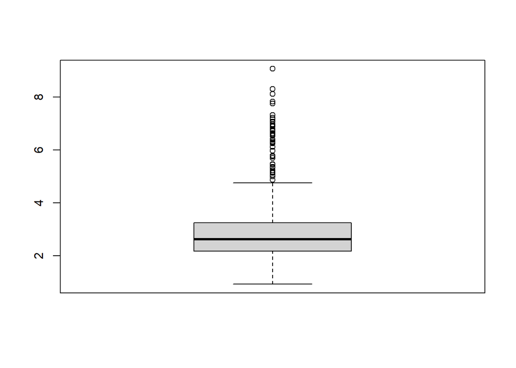

```r
boxplot(data_regre$gasto_cultura)
```

```r
IQR_cultura <- IQR(data_regre$gasto_cultura, na.rm = TRUE)
limite_superior <- quantile(data_regre$gasto_cultura, 0.75, na.rm = TRUE) + 1.5 * IQR_cultura
outliers <- data_regre %>%
  filter(gasto_cultura > limite_superior)
print(outliers)
```

```
# A tibble: 57 × 16
   desempeño_media año   pais    posicion_concurso posicion_gfinal puntos_gfinal
             <dbl> <chr> <chr>               <dbl>           <dbl>         <dbl>
 1            2.50 2016  armenia                 7               7           249
 2            4.49 2022  azerba…                16              16           106
 3            2.12 2003  bosnia…                16              16            27
 4            2.12 2009  bosnia…                 9               9           106
 5            4.15 2023  denmark                33               0             0
 6            2.25 2002  estonia                 3               3           111
 7            2.25 2003  estonia                21              21            14
 8            2.25 2004  estonia                25               0             0
 9            2.25 2005  estonia                34               0             0
10            2.25 2006  estonia                32               0             0
# ℹ 47 more rows
# ℹ 10 more variables: IDH <dbl>, gasto_cultura <dbl>, gasto_educacion <dbl>,
#   libertad_prensa <dbl>, gasto_militar <dbl>, control_corrupcion <dbl>,
#   efectividad_gobierno <dbl>, estado_derecho <dbl>,
#   estabilidad_politica_violencia <dbl>, lag_desempeño_nota <dbl>
```

Tendríamos que tratar los outliers, pero no tenemos tiempo para ello, por lo que seguirá realizando el trabajo, siendo conscientes del gran sesgo que esto puede suponer para el resultado final.

# Gráficos

Vamos a realizar gráficos con la variable desempeño y las variables sociopolíticas de interes.

## Creacion de base de datos con Israel y paises similares

```r
# Paso 1: Obtener el desempeño de Israel desde desempeño_tabla
desempeño_israel <- data_regre %>%
  dplyr::filter(pais == "israel") %>%
  dplyr::pull(desempeño_media) # Obtener el puntaje de desempeño de Israel

# Verificar si se encontró el país "israel"
if (length(desempeño_israel) == 0) {
  stop("El país 'israel' no se encuentra en la tabla 'desempeño_tabla'.")
}

# Definir el rango de ±0.5
rango_desempeño <- 0.5

# Filtrar países con desempeño similar
paises_similares <- data_regre %>%
  dplyr::filter(
    desempeño_media >= (desempeño_israel - rango_desempeño) &
    desempeño_media <= (desempeño_israel + rango_desempeño)
  ) %>%
  dplyr::select(pais, desempeño_media) # Seleccionar solo país y puntaje

# Paso 2: Combinar con los indicadores de data

# Unir por la columna 'pais'
datos_combinados <- paises_similares %>%
  dplyr::left_join(data, by = "pais") %>%
  dplyr::select(
    pais, desempeño_media,
    IDH, gasto_cultura, puntos_gfinal, estabilidad_politica_violencia,
    libertad_prensa, gasto_militar, gasto_educacion,
    control_corrupcion, posicion_concurso
  )

# Paso 3: Mostrar tabla de comparación
print(datos_combinados)
```

```
# A tibble: 3,664 × 11
   pais       desempeño_media   IDH gasto_cultura puntos_gfinal
   <chr>                <dbl> <dbl>         <dbl>         <dbl>
 1 azerbaijan            4.49 0.716          1.22           132
 2 azerbaijan            4.49 0.722          1.37           207
 3 azerbaijan            4.49 0.727          1.31           145
 4 azerbaijan            4.49 0.729          1.16           221
 5 azerbaijan            4.49 0.734          1.27           150
 6 azerbaijan            4.49 0.741          1.35           234
 7 azerbaijan            4.49 0.745          1.44            33
 8 azerbaijan            4.49 0.748          1.39            49
 9 azerbaijan            4.49 0.75           3.52           117
10 azerbaijan            4.49 0.753          1.12           120
# ℹ 3,654 more rows
# ℹ 6 more variables: estabilidad_politica_violencia <chr>,
#   libertad_prensa <dbl>, gasto_militar <dbl>, gasto_educacion <dbl>,
#   control_corrupcion <chr>, posicion_concurso <dbl>
```

# Gráficos

Vamos a realizar gráficos con la variable desempeño y las variables sociopolíticas de interes.

```r
desempeño_israel <- data_regre %>%
  filter(pais == "israel") %>%
  pull(desempeño_media)

rango_desempeño <- 0.5

paises_similares <- data_regre %>%
  filter(
    desempeño_media >= (desempeño_israel - rango_desempeño) &
    desempeño_media <= (desempeño_israel + rango_desempeño)
  ) %>%
  dplyr::select(pais, desempeño_media)

datos_combinados <- paises_similares %>%
  left_join(data_regre, by = "pais") %>%
  dplyr::select(-desempeño_media.y) %>%
  rename(desempeño_media = desempeño_media.x) %>%
  group_by(pais) %>%
  summarise(
    desempeño_media = mean(desempeño_media, na.rm = TRUE),
    IDH = mean(IDH, na.rm = TRUE),
    gasto_cultura = mean(gasto_cultura, na.rm = TRUE),
    estabilidad_politica_violencia = mean(estabilidad_politica_violencia, na.rm = TRUE),
    libertad_prensa = mean(libertad_prensa, na.rm = TRUE),
    gasto_militar = mean(gasto_militar, na.rm = TRUE),
    gasto_educacion = mean(gasto_educacion, na.rm = TRUE),
    control_corrupcion = mean(control_corrupcion, na.rm = TRUE)
  ) %>%
  ungroup() %>%
  mutate(pais = fct_relevel(pais, "israel"))
```

Ahora creamos los gráficos.

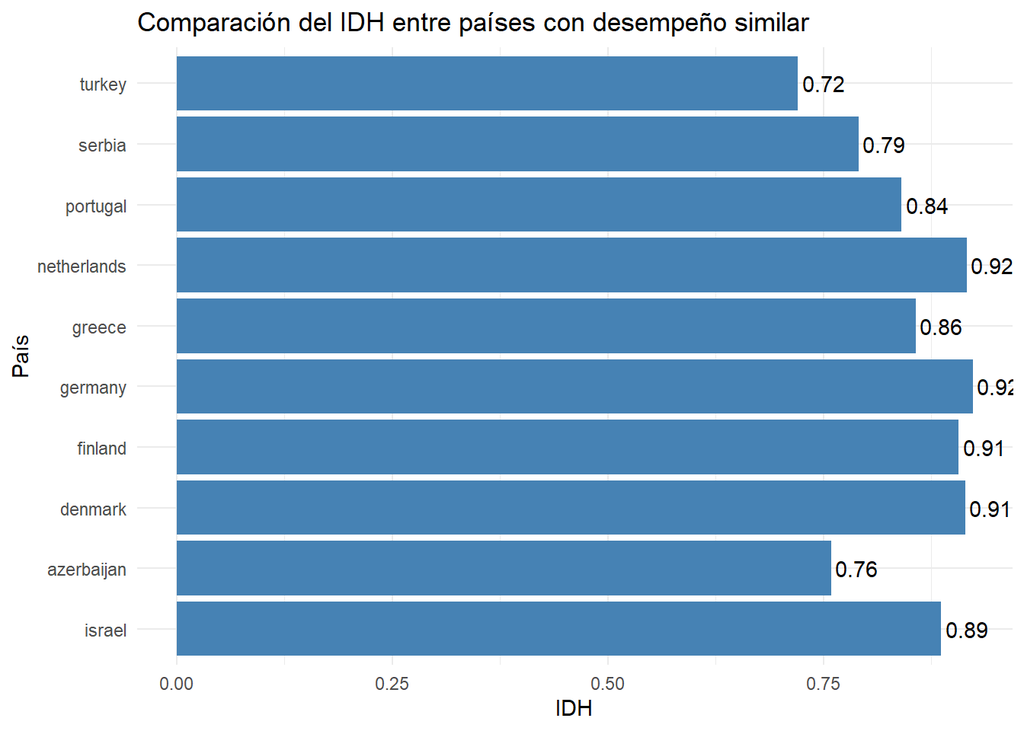

```r
ggplot(datos_combinados, aes(x = pais, y = IDH)) +
  geom_bar(stat = "identity", fill = "steelblue") +
  geom_text(aes(label = round(IDH, 2)), hjust = -0.1) +
  coord_flip() +
  labs(
    title = "Comparación del IDH entre países con desempeño similar",
    x = "País",
    y = "IDH"
  ) +
  theme_minimal()
```

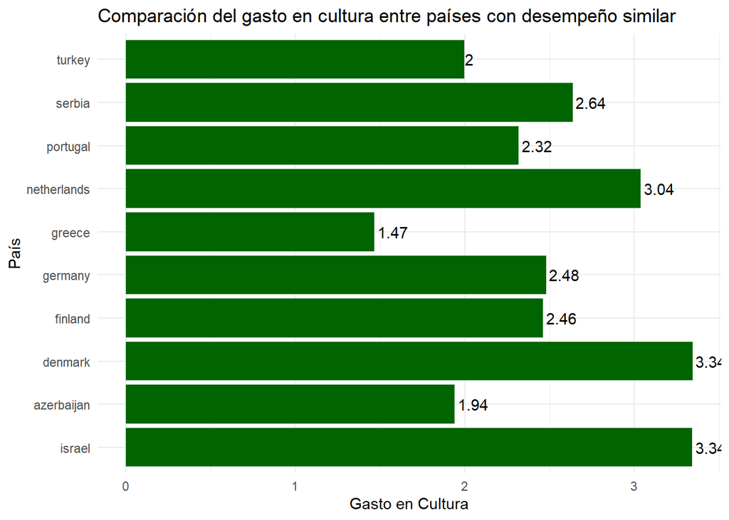

```r
ggplot(datos_combinados, aes(x = pais, y = gasto_cultura)) +
  geom_bar(stat = "identity", fill = "darkgreen") +
  geom_text(aes(label = round(gasto_cultura, 2)), hjust = -0.1) +
  coord_flip() +
  labs(
    title = "Comparación del gasto en cultura entre países con desempeño similar",
    x = "País",
    y = "Gasto en Cultura"
  ) +
  theme_minimal()
```

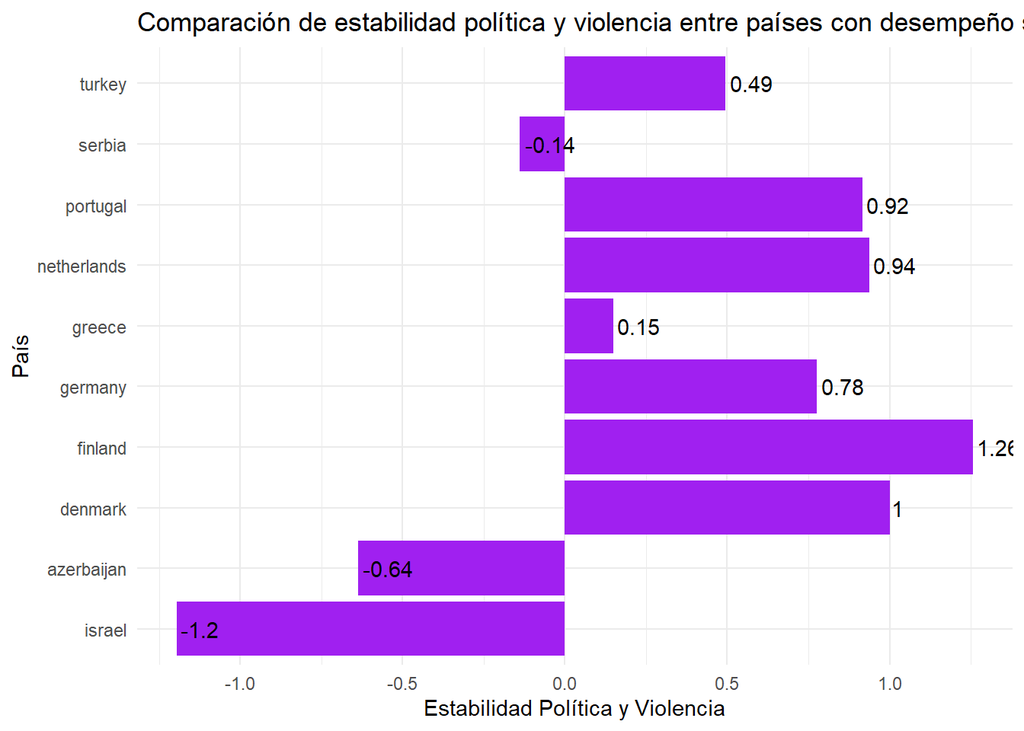

```r
ggplot(datos_combinados, aes(x = pais, y = estabilidad_politica_violencia)) +
  geom_bar(stat = "identity", fill = "purple") +
  geom_text(aes(label = round(estabilidad_politica_violencia, 2)), hjust = -0.1) +
  coord_flip() +
  labs(
    title = "Comparación de estabilidad política y violencia entre países con desempeño similar",
    x = "País",
    y = "Estabilidad Política y Violencia"
  ) +
  theme_minimal()
```

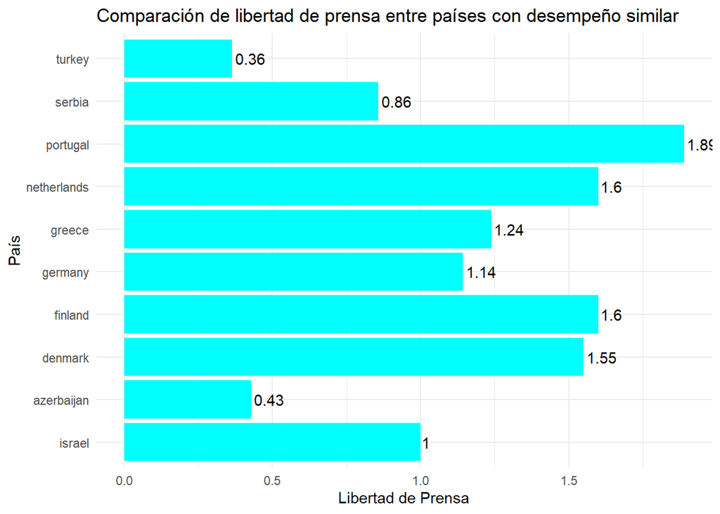

```r
ggplot(datos_combinados, aes(x = pais, y = libertad_prensa)) +
  geom_bar(stat = "identity", fill = "cyan") +
  geom_text(aes(label = round(libertad_prensa, 2)), hjust = -0.1) +
  coord_flip() +
  labs(
    title = "Comparación de libertad de prensa entre países con desempeño similar",
    x = "País",
    y = "Libertad de Prensa"
  ) +
  theme_minimal()
```

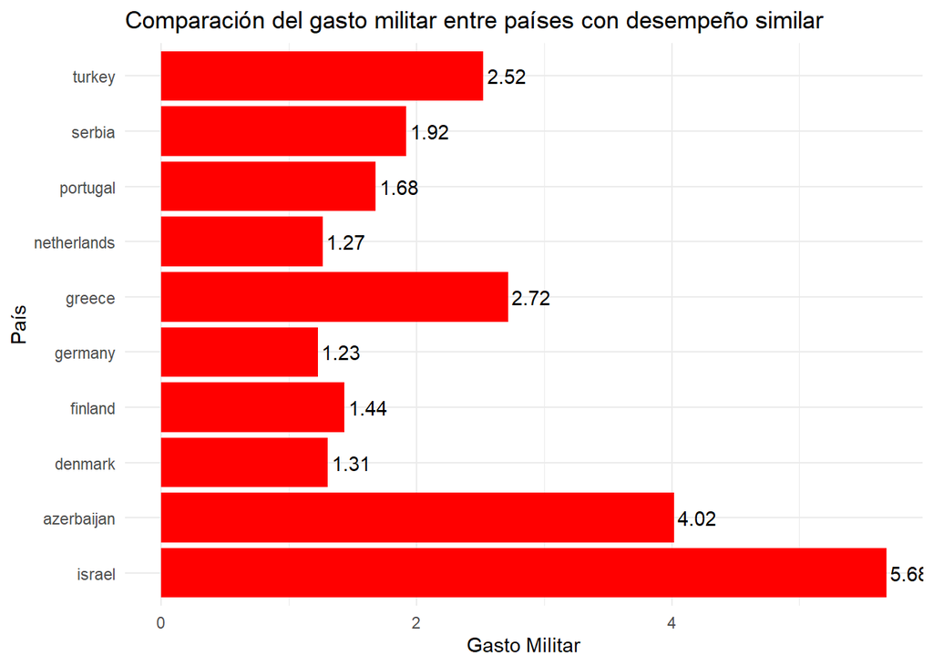

```r
ggplot(datos_combinados, aes(x = pais, y = gasto_militar)) +
  geom_bar(stat = "identity", fill = "red") +
  geom_text(aes(label = round(gasto_militar, 2)), hjust = -0.1) +
  coord_flip() +
  labs(
    title = "Comparación del gasto militar entre países con desempeño similar",
    x = "País",
    y = "Gasto Militar"
  ) +
  theme_minimal()
```

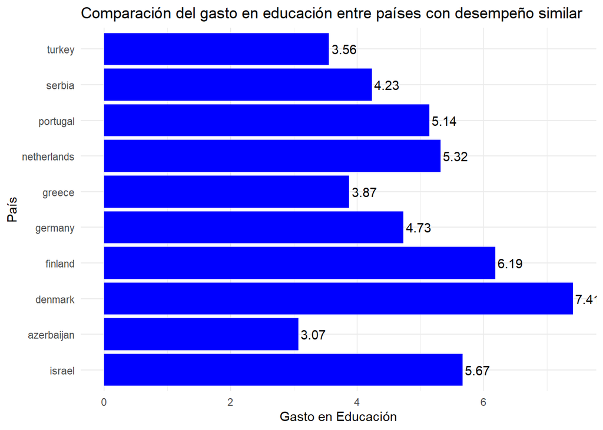

```r
ggplot(datos_combinados, aes(x = pais, y = gasto_educacion)) +
  geom_bar(stat = "identity", fill = "blue") +
  geom_text(aes(label = round(gasto_educacion, 2)), hjust = -0.1) +
  coord_flip() +
  labs(
    title = "Comparación del gasto en educación entre países con desempeño similar",
    x = "País",
    y = "Gasto en Educación"
  ) +
  theme_minimal()
```

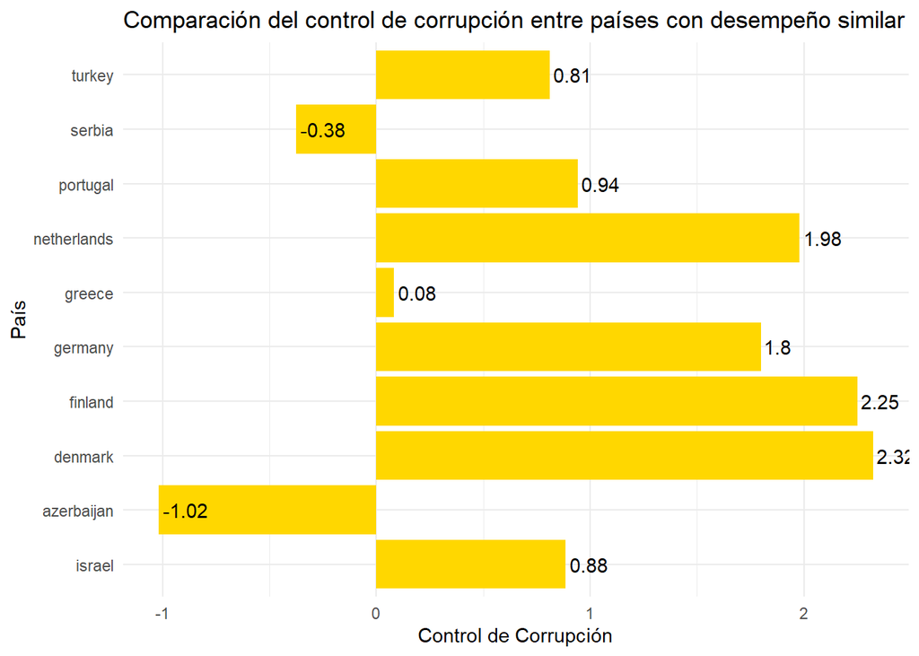

```r
ggplot(datos_combinados, aes(x = pais, y = control_corrupcion)) +
  geom_bar(stat = "identity", fill = "gold") +
  geom_text(aes(label = round(control_corrupcion, 2)), hjust = -0.1) +
  coord_flip() +
  labs(
    title = "Comparación del control de corrupción entre países con desempeño similar",
    x = "País",
    y = "Control de Corrupción"
  ) +
  theme_minimal()
```